# Welcome to Array/List Lab

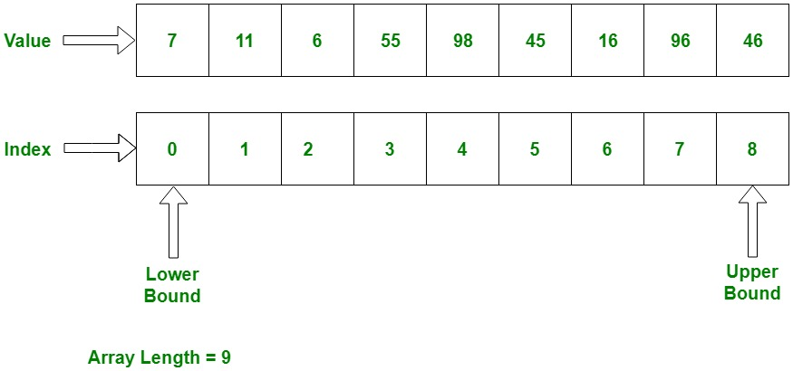

#### 1. Write a function srch(array,element) that searches the array for the element and returns the index (position) in the array if the element is found, and -1 otherwise.

- Suppose arr = [1,4,3,2]
  - srch(arr,3) should return 3
  - srch(arr,6) should return -1

```python
def srch(arr,elem):
    for i in range(len(arr)):
        if arr[i] == elem:
            print("found at i")
            return i+1
    return(-1)
```

```python
myarr = [9,2,7,5]
srch(myarr,2)
```

[output not shown]

#### 2. Write a function insatind(array,position,element) to insert an element into an array at the specified index (position).

- Suppose arr = [1,4,3,2]
  - insatind(arr,3,6) should return [1,4,6,3,2]

#### 3. Write a function delatind(array,position) to delete the element at the specified index (position) in the array.

- Suppose arr = [1,4,3,2]
  - delatind(arr,3) should return [1,4,2]

#### 4. Write a function insatend(array,element) that inserts an element at the end of an array.

- Suppose arr = [4, 6, 2, 9]
  - insatend(arr,55) should return [4, 6, 2, 9, 55]

#### 5. Write a function insatbeg(array,element) that inserts an element at the beginning of the array.

- Suppose arr = [4, 6, 2, 9]
  - insatend(arr,55) should return [55, 4, 6, 2, 9]

### Properties of Arrays

- What properties do you know?

### Properties of Arrays

- Given an index, you can straightway access the element, for example, $A[3]$
- Typically (not always!) implemented as contiguous locations in memory for ease of location calculation and hence access.
- So, given an index $i$, how much time does it take to access $A[i]$?

#### 6. Write a function lsrch(linked_list,element) that searches a linked list for the element and returns the index (position) in the linked lsit if the element is found, and -1 otherwise.

- Suppose lnklist = 1 --> 2 --> 3 --> 4
  - lsrch(lnklist,3) should return 3
  - lsrch(lnklist,6) should return -1

#### 7. Write a function linsatend(linked_list,element) that inserts an element at the end of a linked list.

- Suppose lnklist = 1 --> 2 --> 3 --> 4
  - linsatend(lnklist,55) should return 1 --> 2 --> 3 --> 4 --> 55

#### 8. Write a function linsatbeg(linked_list,element) that inserts an element at the beginning of the linked list.

- Suppose lnklist = 1 --> 2 --> 3 --> 4
  - linsatend(lnklist,55) should return 55 --> 1 --> 2 --> 3 --> 4

#### 9. Write a function replatind(array,position,element) to replace an element into an array at the specified index (position).

- Suppose arr = [1,2,3,4]
  - replatind(arr,3,6) should return [1,2,6,4]
  - replatind(arr,6,6) should return -1

#### 10. Write a function replatind(linked_list,position,element) to replace an element in the linked_list at the specified position.

- Suppose lnklist = 1 --> 2 --> 3 --> 4
  - replatind(lnklist,3,6) should return 1 --> 2 --> 6 --> 4
  - replatind(lnklist,6,6) should return -1

#### 11. Write a function dubbly_append(dlinked_list,element) to append an element into the doubly linked list.

- Suppose dlnkd_list = 1 <--> 6 --> 22 --> 3
  - dubbly_append(dlnkd_list,6) should return 1 <--> 6 <--> 22 <--> 3 <--> 6

### Now, find the time complexities of all of the algorithms above!

[figure not shown]